# Lab_01

Name: George Mathew  
Student ID: 8966959  
Section: 2

## Practical Lab 1 - Univariate Linear Regression on the California Housing Prices Dataset

All the codes and procedures used in this notebook are referenced/taken from [Ran Feldesh's repo](https://github.com/CSCN8010/CSCN8010/blob/main/class_notebooks/linear_regression/linear_regression_example.ipynb)

#### 1. Framing the Problem - Describe the goal of this report (0.5 point).

The goal of this report is to develop and evaluate three univariate linear regression models. These models will predict the median house value based on three independent variables: median income, population, and number of households. The focus is on assessing how well each variable explains the variability in house prices. By comparing the goodness-of-fit for each model, we aim to determine which factor is the most significant predictor of median house values.

#### 2. Getting the Data - hyperlink to the source (0.25 point) and load into Pandas (0.25 point).

```python
import pandas as pd

# Load the dataset
url = 'C:/Users/ASUS/Documents/AAIML/Foundations of Machine Learning Frameworks/Data/housing.csv'
data = pd.read_csv(url)
```

#### 3. Exploratory Data Analysis (EDA) (2 points):

##### 1. Explore statistics (e.g. using Pandas `describe` function)

```python
# Get summary statistics
stats = data.describe()
print(stats)
```

```
          longitude      latitude  housing_median_age   total_rooms  \
count  20640.000000  20640.000000        20640.000000  20640.000000
mean    -119.569704     35.631861           28.639486   2635.763081
std        2.003532      2.135952           12.585558   2181.615252
min     -124.350000     32.540000            1.000000      2.000000
25%     -121.800000     33.930000           18.000000   1447.750000
50%     -118.490000     34.260000           29.000000   2127.000000
75%     -118.010000     37.710000           37.000000   3148.000000
max     -114.310000     41.950000           52.000000  39320.000000

       total_bedrooms    population    households  median_income  \
count    20433.000000  20640.000000  20640.000000   20640.000000
mean       537.870553   1425.476744    499.539680       3.870671
std        421.385070   1132.462122    382.329753       1.899822
min          1.000000      3.000000      1.000000       0.499900
25%        296.000000    787.000000    280.000000       2.563400
50%        435.000000   1166.000000    409.000000       3.534800
75%        647.000000   1725.000000    605.000000       4.743250
max       6445.000000  35682.000000   6082.000000      15.000100

       median_house_value
count        20640.000000
mean        206855.816909
std         115395.615874
min          14999.000000
25%         119600.000000
50%         179700.000000
75%         264725.000000
max         500001.000000
```

##### 2. Create three Seaborn scatter plots of median house value vs. median income, population and number of households. There should be one scatter plot per each independent variable. Add a title to each graph (using Seaborn). Provide textual interpretation of the graphs, and insights specific to the linear regression you are going to conduct next. (1 point).

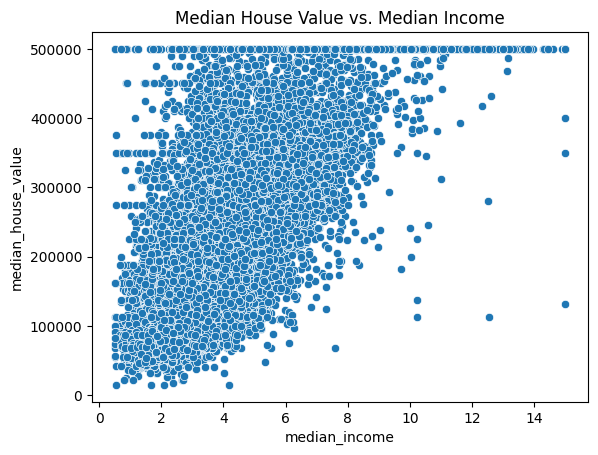

```python
import seaborn as sns
import matplotlib.pyplot as plt

# Median House Value vs Median Income
sns.scatterplot(x='median_income', y='median_house_value', data=data)
plt.title('Median House Value vs. Median Income')
plt.show()
```

There's a positive correlation between median income and median house value. This means that as median income increases, median house value generally tends to increase as well to an extend.  
There is a ceiling at around $500,000 for the median house value, suggesting that there might be a maximum price point in the dataset.  
There are a few outliers with relatively low median incomes but high median house values, which could be due to various other factors that are not captured in the data.

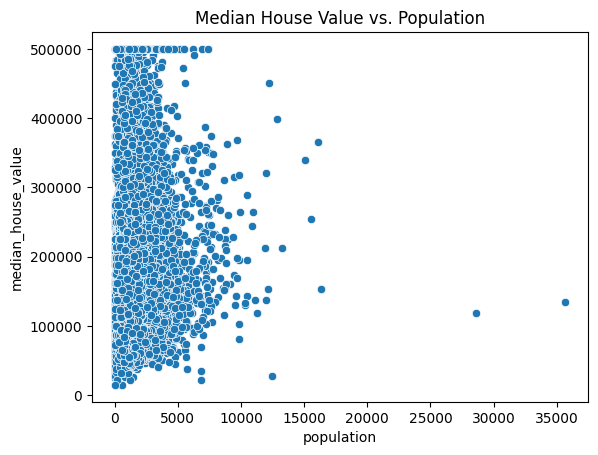

```python
# Median House Value vs Population
sns.scatterplot(x='population', y='median_house_value', data=data)
plt.title('Median House Value vs. Population')
plt.show()
```

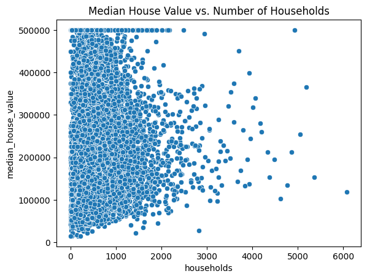

```python
# Median House Value vs Number of Households
sns.scatterplot(x='households', y='median_house_value', data=data)
plt.title('Median House Value vs. Number of Households')
plt.show()
```

##### 3. Based on the above, describe the 4 variables used in this lab. Observations such as their meaning, range and additional characteristics that you notice. This should be concise, and relevant (1 point).

1. Population:

Meaning: Total number of people residing within a block.  
Range: Appears to range from 0 to around 35,000.  
Observations: The distribution is skewed to the right, with a concentration of data points in the lower range.

2. Households:

Meaning: Total number of households within a block.  
Range: Appears to range from 0 to around 6,000.  
Observations: Similar to population, the distribution is skewed to the right, suggesting a concentration of blocks with fewer households.

3. Median Income:

Meaning: Median income for households within a block.  
Range: Appears to range from 0 to around 150,000 US Dollars.  
Observations: The distribution is skewed to the right, with a concentration of data points in the lower-to-middle range.

4. Median House Value:

Meaning: Median house value for households within a block.  
Range: Appears to range from 0 to around 500,000 US Dollars.  
Observations: The distribution is skewed to the right, with a concentration of data points in the lower-to-middle range. There is a clear ceiling at around 500,000 US Dollars.

#### 4. Run three linear regressions (fitting) between (1.5 point):

##### 1. median house value vs. median income 2. median house value vs. population 3. median house value vs. number of households.

```python
# Data Preprocessing
data_preprocessed = data[data.median_house_value != 500001]

# Split the data into train and test sets
train_size = int(len(data_preprocessed) * 0.8)
train = data_preprocessed[:train_size]
test = data_preprocessed[train_size:]
```

```python
from sklearn.linear_model import LinearRegression

# Create a linear regression model
model_income = LinearRegression()
model_population = LinearRegression()
model_households = LinearRegression()

# Fit the models
model_income.fit(X=train[["median_income"]], y=train[["median_house_value"]])
model_population.fit(X=train[["population"]], y=train[["median_house_value"]])
model_households.fit(X=train[["households"]], y=train[["median_house_value"]])
```

```
LinearRegression()
```

#### 5. In a single table for all three linear regressions, provide per regression model (1.5 points):

##### 1. intercept and slope (0.5 point) 2. Mean Squared Error (0.5 point) 3. Mean Absolute Error (0.5 point)

```python
from sklearn.metrics import mean_squared_error, mean_absolute_error

# Get intercept and slope values
intercept_income, slope_income = model_income.intercept_, model_income.coef_
intercept_population, slope_population = model_population.intercept_, model_population.coef_
intercept_households, slope_households = model_households.intercept_, model_households.coef_

# Predictions
12*model_income.coef_ + model_income.intercept_
model_income.predict(X=[[12],[1],[100]])

12*model_population.coef_ + model_population.intercept_
model_population.predict(X=[[12],[1],[100]])

12*model_households.coef_ + model_households.intercept_
model_households.predict(X=[[12],[1],[100]])


# Calculate MSE and MAE
mse_income = mean_squared_error(train[['median_house_value']], model_income.predict(train[['median_income']]))
mae_income = mean_absolute_error(train[['median_house_value']], model_income.predict(train[['median_income']]))
mse_population = mean_squared_error(train[['median_house_value']], model_population.predict(train[['population']]))
mae_population = mean_absolute_error(train[['median_house_value']], model_population.predict(train[['population']]))
mse_households = mean_squared_error(train[['median_house_value']], model_households.predict(train[['households']]))
mae_households = mean_absolute_error(train[['median_house_value']], model_households.predict(train[['households']]))

# Print intercept, Slope, MSE and MAE
print(f"Median House Value vs. Median Income: Intercept = {intercept_income}, Slope = {slope_income}, MSE = {mse_income}, MAE = {mae_income}")
print(f"Median House Value vs. Population: Intercept = {intercept_population}, Slope = {slope_population}, MSE = {mse_population}, MAE = {mae_population}")
print(f"Median House Value vs. Households: Intercept = {intercept_households}, Slope = {slope_households}, MSE = {mse_households}, MAE = {mae_households}")
```

```
Median House Value vs. Median Income: Intercept = [48204.53436817], Slope = [[38702.97233842]], MSE = 5557954319.259176, MAE = 55839.99864072871
Median House Value vs. Population: Intercept = [188081.58862584], Slope = [[0.32862973]], MSE = 9236185598.969007, MAE = 75879.52660618868
Median House Value vs. Households: Intercept = [177147.28853835], Slope = [[22.62572591]], MSE = 9156895298.287685, MAE = 75463.10651473372
```

[output not shown]

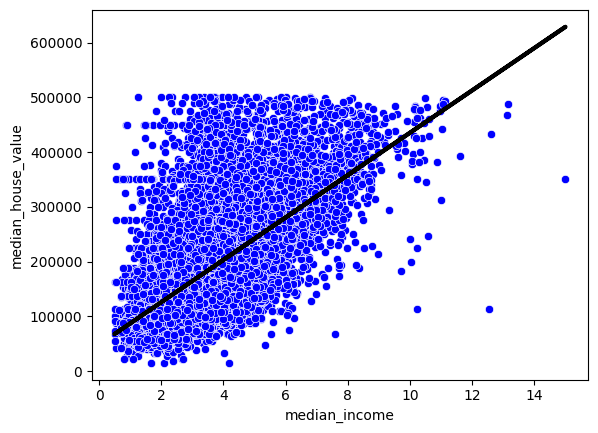

```python
# Add regression line for Median Income
sns.scatterplot(x="median_income", y="median_house_value", data=train, color="blue")
plt.plot(train[["median_income"]], model_income.predict(train[["median_income"]]), color="black", linewidth=3)
plt.show()
```

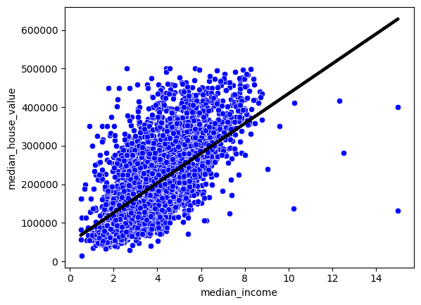

```python
# Add regression line for Median Income
sns.scatterplot(x="median_income", y="median_house_value", data=test, color="blue")
plt.plot(test[["median_income"]], model_income.predict(test[["median_income"]]), color="black", linewidth=3)
plt.show()
```

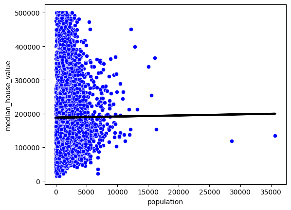

```python
# Add regression line for population
sns.scatterplot(x="population", y="median_house_value", data=train, color="blue")
plt.plot(train[["population"]], model_population.predict(train[["population"]]), color="black", linewidth=3)
plt.show()
```

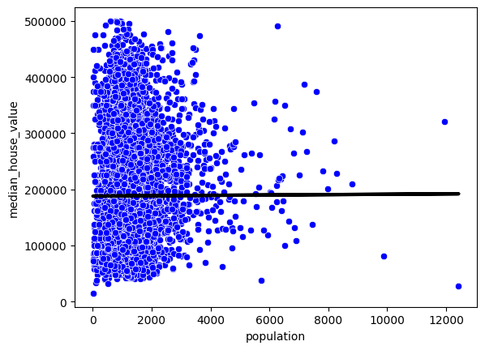

```python
# Add regression line for population
sns.scatterplot(x="population", y="median_house_value", data=test, color="blue")
plt.plot(test[["population"]], model_population.predict(test[["population"]]), color="black", linewidth=3)
plt.show()
```

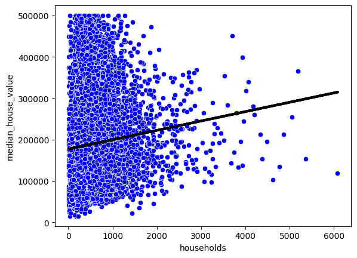

```python
# Add regression line for households
sns.scatterplot(x="households", y="median_house_value", data=train, color="blue")
plt.plot(train[["households"]], model_households.predict(train[["households"]]), color="black", linewidth=3)
plt.show()
```

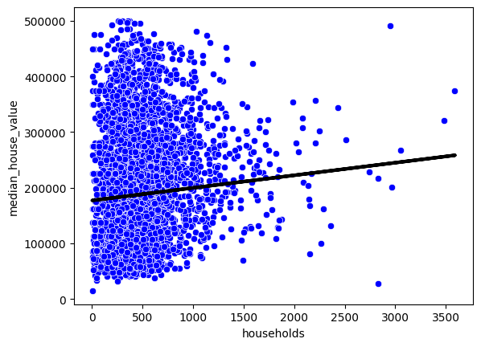

```python
# Add regression line for households
sns.scatterplot(x="households", y="median_house_value", data=test, color="blue")
plt.plot(test[["households"]], model_households.predict(test[["households"]]), color="black", linewidth=3)
plt.show()
```

#### 7. Summary: provide a conclusion. Compare the models in terms of their goodness-of-fit, and add additional insights you observed (1 point)

Based on the provided regression models, we can conclude that median income is the most significant predictor of median house value among the three variables considered (population, households, and median income).

Goodness-of-fit comparison:

MSE (Mean Squared Error): The MSE for the model using median income (5557954319.259176) is significantly lower than the MSE for the models using population (9236185598.969007) and households (9156895298.287685). This indicates that the median income model provides a better fit to the data. MAE (Mean Absolute Error): Similarly, the MAE for the median income model (55839.99864072871) is lower than the MAE for the other models, further supporting its superior performance. Additional insights:

The slope coefficient for the median income model (38702.97233842) is significantly larger than the slope coefficients for the other models, suggesting a stronger linear relationship between median income and median house value. While population and households are also correlated with median house value, their relationships are less strong and less consistent compared to the relationship with median income. This might be due to various other factors that are not captured in the data which are more closely tied to median income.

In conclusion, the regression analysis suggests that median income is the most influential factor in determining median house value in the given dataset. This finding aligns with common intuition and economic theories. However, it's important to note that other factors, such as location, size, and specific features of individual houses, can also play a significant role in determining housing prices.